# AadityaKumarRavi_Project_NeuralNetworks

## AIML Module Project - Neural Networks - Aaditya Kumar Ravi

**• DOMAIN:** Electronics and Telecommunication  
**• CONTEXT:** A communications equipment manufacturing company has a product which is responsible for emitting informative signals. Company wants to build a machine learning model which can help the company to predict the equipment’s signal quality using various parameters.  
**• DATA DESCRIPTION:** The data set contains information on various signal tests performed:

1. Parameters: Various measurable signal parameters.
2. Signal_Quality: Final signal strength or quality

**• PROJECT OBJECTIVE:** To build a classifier which can use the given parameters to determine the signal strength or quality.  
**Steps and tasks: [ Total Score: 30 Marks]**

#### 1. Data import and Understanding [10 Marks]

#### A. Read the ‘Signals.csv’ as DataFrame and import required libraries. [2 Marks]

```python
import numpy as np
import pandas as pd
import matplotlib.pyplot as plt
%matplotlib inline
import seaborn as sns

from sklearn.model_selection import train_test_split
from sklearn import preprocessing
from sklearn.metrics import accuracy_score, classification_report, confusion_matrix

import tensorflow as tf
from tensorflow.keras.models import Sequential
from tensorflow.keras.utils import to_categorical
from tensorflow.keras.layers import Dense, Dropout, BatchNormalization
from tensorflow.keras import optimizers
from tensorflow.keras.callbacks import ModelCheckpoint, ReduceLROnPlateau

import warnings
warnings.filterwarnings('ignore')
```

```python
signal_df = pd.read_csv('NN Project Data - Signal.csv')
signal_df.head()
```

|  | Parameter 1 | Parameter 2 | Parameter 3 | Parameter 4 | Parameter 5 | Parameter 6 | Parameter 7 | Parameter 8 | Parameter 9 | Parameter 10 | Parameter 11 | Signal_Strength |
| --- | --- | --- | --- | --- | --- | --- | --- | --- | --- | --- | --- | --- |
| 0 | 7.4 | 0.70 | 0.00 | 1.9 | 0.076 | 11.0 | 34.0 | 0.9978 | 3.51 | 0.56 | 9.4 | 5 |
| 1 | 7.8 | 0.88 | 0.00 | 2.6 | 0.098 | 25.0 | 67.0 | 0.9968 | 3.20 | 0.68 | 9.8 | 5 |
| 2 | 7.8 | 0.76 | 0.04 | 2.3 | 0.092 | 15.0 | 54.0 | 0.9970 | 3.26 | 0.65 | 9.8 | 5 |
| 3 | 11.2 | 0.28 | 0.56 | 1.9 | 0.075 | 17.0 | 60.0 | 0.9980 | 3.16 | 0.58 | 9.8 | 6 |
| 4 | 7.4 | 0.70 | 0.00 | 1.9 | 0.076 | 11.0 | 34.0 | 0.9978 | 3.51 | 0.56 | 9.4 | 5 |

#### B. Check for missing values and print percentage for each attribute. [2 Marks]

```python
signal_df.info()
```

```
<class 'pandas.core.frame.DataFrame'>
RangeIndex: 1599 entries, 0 to 1598
Data columns (total 12 columns):
 #   Column           Non-Null Count  Dtype
---  ------           --------------  -----
 0   Parameter 1      1599 non-null   float64
 1   Parameter 2      1599 non-null   float64
 2   Parameter 3      1599 non-null   float64
 3   Parameter 4      1599 non-null   float64
 4   Parameter 5      1599 non-null   float64
 5   Parameter 6      1599 non-null   float64
 6   Parameter 7      1599 non-null   float64
 7   Parameter 8      1599 non-null   float64
 8   Parameter 9      1599 non-null   float64
 9   Parameter 10     1599 non-null   float64
 10  Parameter 11     1599 non-null   float64
 11  Signal_Strength  1599 non-null   int64
dtypes: float64(11), int64(1)
memory usage: 150.0 KB
```

**Observation:**

- Total Row count is 1599 and also looks like none of the rows have null values as total row count and not null count is matching for all the columns.
- All the columns are of numeric type, so there is no chance of missing values in some special character form.
- Parameter 1 to 11 is of continuous type, Signal_Strength is target class variable, represent a category.

```python
#print
for col in list(signal_df.columns):
    print("==========", col,"============")
    print(signal_df[col].unique())
```

```
========== Parameter 1 ============
[ 7.4  7.8 11.2  7.9  7.3  7.5  6.7  5.6  8.9  8.5  8.1  7.6  6.9  6.3
  7.1  8.3  5.2  5.7  8.8  6.8  4.6  7.7  8.7  6.4  6.6  8.6 10.2  7.
  7.2  9.3  8.   9.7  6.2  5.   4.7  8.4 10.1  9.4  9.   8.2  6.1  5.8
  9.2 11.5  5.4  9.6 12.8 11.  11.6 12.  15.  10.8 11.1 10.  12.5 11.8
 10.9 10.3 11.4  9.9 10.4 13.3 10.6  9.8 13.4 10.7 11.9 12.4 12.2 13.8
  9.1 13.5 10.5 12.6 14.  13.7  9.5 12.7 12.3 15.6  5.3 11.3 13.   6.5
 12.9 14.3 15.5 11.7 13.2 15.9 12.1  5.1  4.9  5.9  6.   5.5]
========== Parameter 2 ============
[0.7   0.88  0.76  0.28  0.66  0.6   0.65  0.58  0.5   0.615 0.61  0.62
 0.56  0.59  0.32  0.22  0.39  0.43  0.49  0.4   0.41  0.71  0.645 0.675
 0.685 0.655 0.605 0.38  1.13  0.45  0.67  0.52  0.935 0.29  0.31  0.51
 0.42  0.63  0.69  0.735 0.725 0.705 0.785 0.75  0.625 0.3   0.55  1.02
 0.775 0.9   0.545 0.575 0.33  0.54  1.07  0.695 1.33  0.745 1.04  0.715
 0.415 0.34  0.68  0.95  0.53  0.64  0.885 0.805 0.73  0.37  0.835 1.09
 0.57  0.44  0.635 0.82  0.48  1.    0.21  0.35  0.975 0.26  0.87  0.18
 0.27  0.2   0.36  0.83  0.46  0.47  0.77  0.815 0.795 0.665 0.765 0.24
 0.85  0.84  0.96  0.78  0.23  0.315 0.365 0.25  0.825 0.72  0.595 0.585
 0.915 0.755 0.845 1.24  0.8   0.98  1.185 0.92  1.035 1.025 0.565 0.74
 1.115 0.865 0.875 0.965 0.91  0.89  1.01  0.305 0.395 0.12  0.86  0.295
 1.005 0.19  0.955 0.16  1.58  0.79  1.18  0.475 0.81  0.895 0.855]
========== Parameter 3 ============
[0.   0.04 0.56 0.06 0.02 0.36 0.08 0.29 0.18 0.19 0.28 0.51 0.48 0.31
 0.21 0.11 0.14 0.16 0.24 0.07 0.12 0.25 0.09 0.3  0.2  0.22 0.15 0.43
 0.52 0.23 0.37 0.26 0.57 0.4  0.49 0.05 0.54 0.64 0.7  0.47 0.44 0.17
 0.68 0.53 0.1  0.01 0.55 1.   0.03 0.42 0.33 0.32 0.35 0.6  0.74 0.58
 0.5  0.76 0.46 0.45 0.38 0.39 0.66 0.62 0.67 0.79 0.63 0.61 0.71 0.65
 0.59 0.34 0.69 0.73 0.72 0.41 0.27 0.75 0.13 0.78]
========== Parameter 4 ============
[ 1.9   2.6   2.3   1.8   1.6   1.2   2.    6.1   3.8   3.9   1.7   4.4
  2.4   1.4   2.5  10.7   5.5   2.1   1.5   5.9   2.8   2.2   3.    3.4
  5.1   4.65  1.3   7.3   7.2   2.9   2.7   5.6   3.1   3.2   3.3   3.6
  4.    7.    6.4   3.5  11.    3.65  4.5   4.8   2.95  5.8   6.2   4.2
  7.9   3.7   6.7   6.6   2.15  5.2   2.55 15.5   4.1   8.3   6.55  4.6
  4.3   5.15  6.3   6.    8.6   7.5   2.25  4.25  2.85  3.45  2.35  2.65
  9.    8.8   5.    1.65  2.05  0.9   8.9   8.1   4.7   1.75  7.8  12.9
 13.4   5.4  15.4   3.75 13.8   5.7  13.9 ]
========== Parameter 5 ============
[0.076 0.098 0.092 0.075 0.069 0.065 0.073 0.071 0.097 0.089 0.114 0.176
 0.17  0.368 0.086 0.341 0.077 0.082 0.106 0.084 0.085 0.08  0.105 0.083
```

[output cut: 95 more lines]

```
 0.42 1.17 1.62 0.94 1.34 1.16 1.1  0.4  1.15 0.37 1.33 1.01]
========== Parameter 11 ============
[ 9.4         9.8        10.          9.5        10.5         9.2
  9.9         9.1         9.3         9.          9.7        10.1
 10.6         9.6        10.8        10.3        13.1        10.2
 10.9        10.7        12.9        10.4        13.         14.
 11.5        11.4        12.4        11.         12.2        12.8
 12.6        12.5        11.7        11.3        12.3        12.
 11.9        11.8         8.7        13.3        11.2        11.6
 11.1        13.4        12.1         8.4        12.7        14.9
 13.2        13.6        13.5        10.03333333  9.55        8.5
 11.06666667  9.56666667 10.55        8.8        13.56666667 11.95
  9.95        9.23333333  9.25        9.05       10.75      ]
========== Signal_Strength ============
[5 6 7 4 8 3]
```

```python
missing = signal_df.isnull().sum() #sum of missing values for each attribute
total = signal_df.shape[0]
percentage = (missing/total)*100
print("Percentage of missing values for each attribute:")
print(percentage)
```

```
Percentage of missing values for each attribute:
Parameter 1        0.0
Parameter 2        0.0
Parameter 3        0.0
Parameter 4        0.0
Parameter 5        0.0
Parameter 6        0.0
Parameter 7        0.0
Parameter 8        0.0
Parameter 9        0.0
Parameter 10       0.0
Parameter 11       0.0
Signal_Strength    0.0
dtype: float64
```

#### C. Check for presence of duplicate records in the dataset and impute with appropriate method. [2 Marks]

```python
signal_df.duplicated().sum()
```

```
240
```

- There are 240 duplicated records present in the dataset.
- We can drop the duplicated rows

```python
signal_df.drop_duplicates(inplace=True)
signal_df
```

|  | Parameter 1 | Parameter 2 | Parameter 3 | Parameter 4 | Parameter 5 | Parameter 6 | Parameter 7 | Parameter 8 | Parameter 9 | Parameter 10 | Parameter 11 | Signal_Strength |
| --- | --- | --- | --- | --- | --- | --- | --- | --- | --- | --- | --- | --- |
| 0 | 7.4 | 0.700 | 0.00 | 1.9 | 0.076 | 11.0 | 34.0 | 0.99780 | 3.51 | 0.56 | 9.4 | 5 |
| 1 | 7.8 | 0.880 | 0.00 | 2.6 | 0.098 | 25.0 | 67.0 | 0.99680 | 3.20 | 0.68 | 9.8 | 5 |
| 2 | 7.8 | 0.760 | 0.04 | 2.3 | 0.092 | 15.0 | 54.0 | 0.99700 | 3.26 | 0.65 | 9.8 | 5 |
| 3 | 11.2 | 0.280 | 0.56 | 1.9 | 0.075 | 17.0 | 60.0 | 0.99800 | 3.16 | 0.58 | 9.8 | 6 |
| 5 | 7.4 | 0.660 | 0.00 | 1.8 | 0.075 | 13.0 | 40.0 | 0.99780 | 3.51 | 0.56 | 9.4 | 5 |
| ... | ... | ... | ... | ... | ... | ... | ... | ... | ... | ... | ... | ... |
| 1593 | 6.8 | 0.620 | 0.08 | 1.9 | 0.068 | 28.0 | 38.0 | 0.99651 | 3.42 | 0.82 | 9.5 | 6 |
| 1594 | 6.2 | 0.600 | 0.08 | 2.0 | 0.090 | 32.0 | 44.0 | 0.99490 | 3.45 | 0.58 | 10.5 | 5 |
| 1595 | 5.9 | 0.550 | 0.10 | 2.2 | 0.062 | 39.0 | 51.0 | 0.99512 | 3.52 | 0.76 | 11.2 | 6 |
| 1597 | 5.9 | 0.645 | 0.12 | 2.0 | 0.075 | 32.0 | 44.0 | 0.99547 | 3.57 | 0.71 | 10.2 | 5 |
| 1598 | 6.0 | 0.310 | 0.47 | 3.6 | 0.067 | 18.0 | 42.0 | 0.99549 | 3.39 | 0.66 | 11.0 | 6 |

1359 rows × 12 columns

We can see now 240 rows has been dropped and only 1359 rows are remaining.

#### D. Visualise distribution of the target variable. [2 Marks]

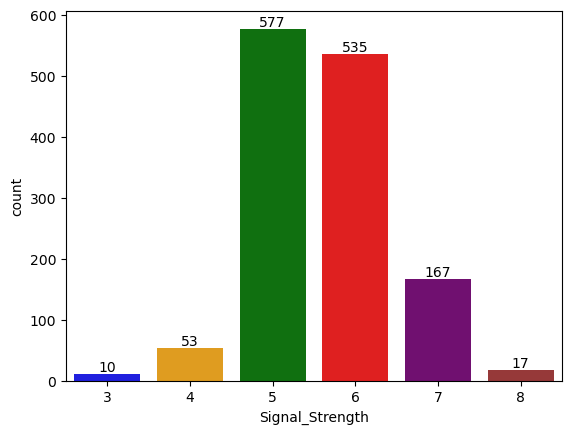

```python
colors = ["blue", "orange", "green", "red", "purple", "brown"]

ax = sns.countplot(signal_df, x='Signal_Strength', palette=colors)

#print the annotation on the plot
for p in ax.patches:
    ax.annotate(format(p.get_height(), '.0f'), #count label formatting
                   (p.get_x() + p.get_width() / 2, p.get_height()), #position of label at center
                   ha = 'center', va = 'center',
                   xytext = (0, 5), #offset of the label from the specified position
                   textcoords = 'offset points')

#Show the plot
plt.show()
```

#### E. Share insights from the initial data analysis (at least 2). [2 Marks]

**Insights:**

- Signal Strength varies from 3 to 8.
- Majority of the equipments have signal strength of 5 followed by signal strength of 6 and then 7.
- There are only 10 devices which has minimum signal strength of 3.
- There are 17 devices having very high signal strength i.e 8
- There are 53 devices with signal strength of 4.

```python
signal_df.describe().T
```

|  | count | mean | std | min | 25% | 50% | 75% | max |
| --- | --- | --- | --- | --- | --- | --- | --- | --- |
| Parameter 1 | 1359.0 | 8.310596 | 1.736990 | 4.60000 | 7.1000 | 7.9000 | 9.20000 | 15.90000 |
| Parameter 2 | 1359.0 | 0.529478 | 0.183031 | 0.12000 | 0.3900 | 0.5200 | 0.64000 | 1.58000 |
| Parameter 3 | 1359.0 | 0.272333 | 0.195537 | 0.00000 | 0.0900 | 0.2600 | 0.43000 | 1.00000 |
| Parameter 4 | 1359.0 | 2.523400 | 1.352314 | 0.90000 | 1.9000 | 2.2000 | 2.60000 | 15.50000 |
| Parameter 5 | 1359.0 | 0.088124 | 0.049377 | 0.01200 | 0.0700 | 0.0790 | 0.09100 | 0.61100 |
| Parameter 6 | 1359.0 | 15.893304 | 10.447270 | 1.00000 | 7.0000 | 14.0000 | 21.00000 | 72.00000 |
| Parameter 7 | 1359.0 | 46.825975 | 33.408946 | 6.00000 | 22.0000 | 38.0000 | 63.00000 | 289.00000 |
| Parameter 8 | 1359.0 | 0.996709 | 0.001869 | 0.99007 | 0.9956 | 0.9967 | 0.99782 | 1.00369 |
| Parameter 9 | 1359.0 | 3.309787 | 0.155036 | 2.74000 | 3.2100 | 3.3100 | 3.40000 | 4.01000 |
| Parameter 10 | 1359.0 | 0.658705 | 0.170667 | 0.33000 | 0.5500 | 0.6200 | 0.73000 | 2.00000 |
| Parameter 11 | 1359.0 | 10.432315 | 1.082065 | 8.40000 | 9.5000 | 10.2000 | 11.10000 | 14.90000 |
| Signal_Strength | 1359.0 | 5.623252 | 0.823578 | 3.00000 | 5.0000 | 6.0000 | 6.00000 | 8.00000 |

#### 2. Data preprocessing [7 Marks]

#### A. Split the data into X & Y. [1 Marks]

```python
X = signal_df.drop('Signal_Strength', axis=1)
Y = signal_df['Signal_Strength']
```

```python
X.head()
```

|  | Parameter 1 | Parameter 2 | Parameter 3 | Parameter 4 | Parameter 5 | Parameter 6 | Parameter 7 | Parameter 8 | Parameter 9 | Parameter 10 | Parameter 11 |
| --- | --- | --- | --- | --- | --- | --- | --- | --- | --- | --- | --- |
| 0 | 7.4 | 0.70 | 0.00 | 1.9 | 0.076 | 11.0 | 34.0 | 0.9978 | 3.51 | 0.56 | 9.4 |
| 1 | 7.8 | 0.88 | 0.00 | 2.6 | 0.098 | 25.0 | 67.0 | 0.9968 | 3.20 | 0.68 | 9.8 |
| 2 | 7.8 | 0.76 | 0.04 | 2.3 | 0.092 | 15.0 | 54.0 | 0.9970 | 3.26 | 0.65 | 9.8 |
| 3 | 11.2 | 0.28 | 0.56 | 1.9 | 0.075 | 17.0 | 60.0 | 0.9980 | 3.16 | 0.58 | 9.8 |
| 5 | 7.4 | 0.66 | 0.00 | 1.8 | 0.075 | 13.0 | 40.0 | 0.9978 | 3.51 | 0.56 | 9.4 |

```python
Y.head()
```

```
0    5
1    5
2    5
3    6
5    5
Name: Signal_Strength, dtype: int64
```

We have split the data into X and Y.

#### B. Split the data into train & test with 70:30 proportion.[1 Marks]

```python
X_train, X_test, Y_train, Y_test = train_test_split(X, Y, test_size=0.3, random_state=1, stratify=Y)
```

#### C. Print shape of all the 4 variables and verify if train and test data is in sync. [1 Marks]

```python
print("X_train shape:",X_train.shape)
print("Y_train shape:",Y_train.shape)

print("X_test shape:",X_test.shape)
print("Y_test shape:",Y_test.shape)
```

```
X_train shape: (951, 11)
Y_train shape: (951,)
X_test shape: (408, 11)
Y_test shape: (408,)
```

```python
X_train
```

|  | Parameter 1 | Parameter 2 | Parameter 3 | Parameter 4 | Parameter 5 | Parameter 6 | Parameter 7 | Parameter 8 | Parameter 9 | Parameter 10 | Parameter 11 |
| --- | --- | --- | --- | --- | --- | --- | --- | --- | --- | --- | --- |
| 295 | 10.8 | 0.500 | 0.46 | 2.5 | 0.073 | 5.0 | 27.0 | 1.00010 | 3.05 | 0.64 | 9.5 |
| 60 | 8.8 | 0.400 | 0.40 | 2.2 | 0.079 | 19.0 | 52.0 | 0.99800 | 3.44 | 0.64 | 9.2 |
| 1582 | 6.1 | 0.715 | 0.10 | 2.6 | 0.053 | 13.0 | 27.0 | 0.99362 | 3.57 | 0.50 | 11.9 |
| 16 | 8.5 | 0.280 | 0.56 | 1.8 | 0.092 | 35.0 | 103.0 | 0.99690 | 3.30 | 0.75 | 10.5 |
| 836 | 6.7 | 0.280 | 0.28 | 2.4 | 0.012 | 36.0 | 100.0 | 0.99064 | 3.26 | 0.39 | 11.7 |
| ... | ... | ... | ... | ... | ... | ... | ... | ... | ... | ... | ... |
| 1007 | 9.1 | 0.300 | 0.34 | 2.0 | 0.064 | 12.0 | 25.0 | 0.99516 | 3.26 | 0.84 | 11.7 |
| 761 | 9.3 | 0.655 | 0.26 | 2.0 | 0.096 | 5.0 | 35.0 | 0.99738 | 3.25 | 0.42 | 9.6 |
| 367 | 10.4 | 0.575 | 0.61 | 2.6 | 0.076 | 11.0 | 24.0 | 1.00000 | 3.16 | 0.69 | 9.0 |
| 158 | 7.1 | 0.680 | 0.00 | 2.2 | 0.073 | 12.0 | 22.0 | 0.99690 | 3.48 | 0.50 | 9.3 |
| 1101 | 7.4 | 0.490 | 0.27 | 2.1 | 0.071 | 14.0 | 25.0 | 0.99388 | 3.35 | 0.63 | 12.0 |

951 rows × 11 columns

```python
Y_train
```

```
295     5
60      5
1582    5
16      7
836     7
       ..
1007    7
761     5
367     5
158     5
1101    6
Name: Signal_Strength, Length: 951, dtype: int64
```

```python
X_test
```

|  | Parameter 1 | Parameter 2 | Parameter 3 | Parameter 4 | Parameter 5 | Parameter 6 | Parameter 7 | Parameter 8 | Parameter 9 | Parameter 10 | Parameter 11 |
| --- | --- | --- | --- | --- | --- | --- | --- | --- | --- | --- | --- |
| 441 | 11.9 | 0.400 | 0.65 | 2.15 | 0.068 | 7.0 | 27.0 | 0.99880 | 3.06 | 0.68 | 11.3 |
| 1135 | 8.0 | 0.250 | 0.43 | 1.70 | 0.067 | 22.0 | 50.0 | 0.99460 | 3.38 | 0.60 | 11.9 |
| 560 | 12.7 | 0.600 | 0.49 | 2.80 | 0.075 | 5.0 | 19.0 | 0.99940 | 3.14 | 0.57 | 11.4 |
| 620 | 8.3 | 0.540 | 0.24 | 3.40 | 0.076 | 16.0 | 112.0 | 0.99760 | 3.27 | 0.61 | 9.4 |
| 1094 | 6.6 | 0.725 | 0.09 | 5.50 | 0.117 | 9.0 | 17.0 | 0.99655 | 3.35 | 0.49 | 10.8 |
| ... | ... | ... | ... | ... | ... | ... | ... | ... | ... | ... | ... |
| 373 | 7.4 | 0.550 | 0.22 | 2.20 | 0.106 | 12.0 | 72.0 | 0.99590 | 3.05 | 0.63 | 9.2 |
| 1065 | 7.7 | 0.610 | 0.18 | 2.40 | 0.083 | 6.0 | 20.0 | 0.99630 | 3.29 | 0.60 | 10.2 |
| 482 | 10.6 | 0.360 | 0.59 | 2.20 | 0.152 | 6.0 | 18.0 | 0.99860 | 3.04 | 1.05 | 9.4 |
| 1052 | 5.6 | 0.605 | 0.05 | 2.40 | 0.073 | 19.0 | 25.0 | 0.99258 | 3.56 | 0.55 | 12.9 |
| 521 | 7.6 | 0.410 | 0.49 | 2.00 | 0.088 | 16.0 | 43.0 | 0.99800 | 3.48 | 0.64 | 9.1 |

408 rows × 11 columns

```python
Y_test
```

```
441     6
1135    6
560     5
620     5
1094    6
       ..
373     5
1065    6
482     5
1052    5
521     5
Name: Signal_Strength, Length: 408, dtype: int64
```

```python
Y_train.value_counts()
```

```
Signal_Strength
5    404
6    374
7    117
4     37
8     12
3      7
Name: count, dtype: int64
```

```python
Y_test.value_counts()
```

```
Signal_Strength
5    173
6    161
7     50
4     16
8      5
3      3
Name: count, dtype: int64
```

- Yes the train and test data is in sync, we have similar distribution of target variable as in actual dataframe.
- Equipments with Signal_strength 5, 6, 7 are still having majority distribution class and 3, 8, 4 minority class even after split.

#### D. Normalise the train and test data with appropriate method. [2 Marks]

```python
X_train = preprocessing.normalize(X_train)
X_test = preprocessing.normalize(X_test)
```

```python
X_train
```

```
array([[0.34528957, 0.01598563, 0.01470678, ..., 0.09751233, 0.0204616 ,
        0.30372694],
       [0.15446954, 0.00702134, 0.00702134, ..., 0.06038355, 0.01123415,
        0.16149088],
       [0.18408212, 0.02157684, 0.00301774, ..., 0.10773331, 0.0150887 ,
        0.35911103],
       ...,
       [0.34569047, 0.01911269, 0.02027608, ..., 0.10503672, 0.02293523,
        0.29915521],
       [0.2536423 , 0.0242925 , 0.        , ..., 0.12432045, 0.01786213,
        0.33223569],
       [0.22978538, 0.01521552, 0.00838406, ..., 0.10402446, 0.01956281,
        0.37262495]])
```

```python
X_test
```

```
array([[0.36493227, 0.01226663, 0.01993328, ..., 0.09383973, 0.02085327,
        0.34653232],
       [0.14129942, 0.00441561, 0.00759484, ..., 0.059699  , 0.01059746,
        0.21018288],
       [0.48108855, 0.02272859, 0.01856168, ..., 0.1189463 , 0.02159216,
        0.43184327],
       ...,
       [0.44113009, 0.01498178, 0.02455347, ..., 0.12651278, 0.04369685,
        0.39119084],
       [0.16139835, 0.01743679, 0.00144106, ..., 0.10260324, 0.01585162,
        0.37179264],
       [0.15974349, 0.00861774, 0.01029925, ..., 0.0731457 , 0.01345208,
        0.1912718 ]])
```

```python
X_train.shape
```

```
(951, 11)
```

```python
X_test.shape
```

```
(408, 11)
```

#### E. Transform Labels into format acceptable by Neural Network [2 Marks]

```python
#Let us convert target variable to one hot encoded matrix
num_classes = 6  #Number of unique values in the target variable
Y_train = to_categorical(Y_train-3, num_classes=num_classes) #subtract 3 so that classes would be indexed from 0 to 5
Y_test = to_categorical(Y_test-3, num_classes=num_classes)   #subtract 3 so that classes would be indexed from 0 to 5
```

```python
Y_train
```

```
array([[0., 0., 1., 0., 0., 0.],
       [0., 0., 1., 0., 0., 0.],
       [0., 0., 1., 0., 0., 0.],
       ...,
       [0., 0., 1., 0., 0., 0.],
       [0., 0., 1., 0., 0., 0.],
       [0., 0., 0., 1., 0., 0.]])
```

```python
Y_test
```

```
array([[0., 0., 0., 1., 0., 0.],
       [0., 0., 0., 1., 0., 0.],
       [0., 0., 1., 0., 0., 0.],
       ...,
       [0., 0., 1., 0., 0., 0.],
       [0., 0., 1., 0., 0., 0.],
       [0., 0., 1., 0., 0., 0.]])
```

```python
Y_train.shape
```

```
(951, 6)
```

```python
Y_test.shape
```

```
(408, 6)
```

#### 3. Model Training & Evaluation using Neural Network [13 Marks]

#### A. Design a Neural Network to train a classifier. [3 Marks]

#### AND

#### B. Train the classifier using previously designed Architecture [2 Marks]

```python
model = Sequential() #initialize neural network

model.add(Dense(64, input_shape=(11,), activation='relu')) #input layer with 64 neurons, 11 features and relu activation function
model.add(Dense(32, activation='relu')) #hidden layer with 32 neurons and relu activation function
#since target variable Signal_Strength column has 6 classes, we will have 6 neurons in the output layer and will use softmax activation function as it
#is multiclass classification problem
model.add(Dense(6, activation='softmax'))
```

```python
model.compile(optimizer='adam', loss='categorical_crossentropy', metrics=['accuracy']) #compile the model
```

```python
model.summary()
```

```
Model: "sequential_5"
```

```
┏━━━━━━━━━━━━━━━━━━━━━━━━━━━━━━━━━━━━━━┳━━━━━━━━━━━━━━━━━━━━━━━━━━━━━┳━━━━━━━━━━━━━━━━━┓
┃ Layer (type)                         ┃ Output Shape                ┃         Param # ┃
┡━━━━━━━━━━━━━━━━━━━━━━━━━━━━━━━━━━━━━━╇━━━━━━━━━━━━━━━━━━━━━━━━━━━━━╇━━━━━━━━━━━━━━━━━┩
│ dense_26 (Dense)                     │ (None, 64)                  │             768 │
├──────────────────────────────────────┼─────────────────────────────┼─────────────────┤
│ dense_27 (Dense)                     │ (None, 32)                  │           2,080 │
├──────────────────────────────────────┼─────────────────────────────┼─────────────────┤
│ dense_28 (Dense)                     │ (None, 6)                   │             198 │
└──────────────────────────────────────┴─────────────────────────────┴─────────────────┘
```

```
 Total params: 3,046 (11.90 KB)
```

```
 Trainable params: 3,046 (11.90 KB)
```

```
 Non-trainable params: 0 (0.00 B)
```

```python
history = model.fit(X_train, Y_train, epochs=50, batch_size=32, validation_split=0.2) #train the model
```

```
24/24 ━━━━━━━━━━━━━━━━━━━━ 1s 12ms/step - accuracy: 0.2486 - loss: 1.7444 - val_accuracy: 0.3403 - val_loss: 1.5865
24/24 ━━━━━━━━━━━━━━━━━━━━ 0s 3ms/step - accuracy: 0.4058 - loss: 1.5328 - val_accuracy: 0.3403 - val_loss: 1.3957
24/24 ━━━━━━━━━━━━━━━━━━━━ 0s 3ms/step - accuracy: 0.4127 - loss: 1.3434 - val_accuracy: 0.3403 - val_loss: 1.2611
24/24 ━━━━━━━━━━━━━━━━━━━━ 0s 3ms/step - accuracy: 0.4316 - loss: 1.2291 - val_accuracy: 0.4660 - val_loss: 1.1908
24/24 ━━━━━━━━━━━━━━━━━━━━ 0s 3ms/step - accuracy: 0.4540 - loss: 1.2005 - val_accuracy: 0.4660 - val_loss: 1.1704
24/24 ━━━━━━━━━━━━━━━━━━━━ 0s 3ms/step - accuracy: 0.5070 - loss: 1.1705 - val_accuracy: 0.4660 - val_loss: 1.1635
24/24 ━━━━━━━━━━━━━━━━━━━━ 0s 3ms/step - accuracy: 0.4986 - loss: 1.1721 - val_accuracy: 0.4817 - val_loss: 1.1545
24/24 ━━━━━━━━━━━━━━━━━━━━ 0s 3ms/step - accuracy: 0.5248 - loss: 1.1596 - val_accuracy: 0.4764 - val_loss: 1.1482
24/24 ━━━━━━━━━━━━━━━━━━━━ 0s 3ms/step - accuracy: 0.4892 - loss: 1.2017 - val_accuracy: 0.4764 - val_loss: 1.1441
24/24 ━━━━━━━━━━━━━━━━━━━━ 0s 4ms/step - accuracy: 0.4863 - loss: 1.2042 - val_accuracy: 0.4921 - val_loss: 1.1442
24/24 ━━━━━━━━━━━━━━━━━━━━ 0s 3ms/step - accuracy: 0.5281 - loss: 1.1290 - val_accuracy: 0.4817 - val_loss: 1.1338
24/24 ━━━━━━━━━━━━━━━━━━━━ 0s 3ms/step - accuracy: 0.5002 - loss: 1.1727 - val_accuracy: 0.4974 - val_loss: 1.1321
24/24 ━━━━━━━━━━━━━━━━━━━━ 0s 3ms/step - accuracy: 0.5152 - loss: 1.1499 - val_accuracy: 0.4660 - val_loss: 1.1374
24/24 ━━━━━━━━━━━━━━━━━━━━ 0s 3ms/step - accuracy: 0.5245 - loss: 1.1825 - val_accuracy: 0.4817 - val_loss: 1.1297
24/24 ━━━━━━━━━━━━━━━━━━━━ 0s 3ms/step - accuracy: 0.4991 - loss: 1.1738 - val_accuracy: 0.4660 - val_loss: 1.1337
24/24 ━━━━━━━━━━━━━━━━━━━━ 0s 3ms/step - accuracy: 0.5309 - loss: 1.1478 - val_accuracy: 0.4817 - val_loss: 1.1281
24/24 ━━━━━━━━━━━━━━━━━━━━ 0s 3ms/step - accuracy: 0.4574 - loss: 1.2195 - val_accuracy: 0.4921 - val_loss: 1.1246
24/24 ━━━━━━━━━━━━━━━━━━━━ 0s 3ms/step - accuracy: 0.5139 - loss: 1.1626 - val_accuracy: 0.4712 - val_loss: 1.1276
24/24 ━━━━━━━━━━━━━━━━━━━━ 0s 3ms/step - accuracy: 0.4836 - loss: 1.1709 - val_accuracy: 0.4712 - val_loss: 1.1325
24/24 ━━━━━━━━━━━━━━━━━━━━ 0s 4ms/step - accuracy: 0.4950 - loss: 1.2009 - val_accuracy: 0.4712 - val_loss: 1.1260
24/24 ━━━━━━━━━━━━━━━━━━━━ 0s 3ms/step - accuracy: 0.4940 - loss: 1.1277 - val_accuracy: 0.5026 - val_loss: 1.1153
24/24 ━━━━━━━━━━━━━━━━━━━━ 0s 3ms/step - accuracy: 0.4941 - loss: 1.1712 - val_accuracy: 0.5026 - val_loss: 1.1150
24/24 ━━━━━━━━━━━━━━━━━━━━ 0s 3ms/step - accuracy: 0.4971 - loss: 1.1561 - val_accuracy: 0.4660 - val_loss: 1.1311
24/24 ━━━━━━━━━━━━━━━━━━━━ 0s 3ms/step - accuracy: 0.4854 - loss: 1.1573 - val_accuracy: 0.4660 - val_loss: 1.1233
24/24 ━━━━━━━━━━━━━━━━━━━━ 0s 3ms/step - accuracy: 0.5246 - loss: 1.0920 - val_accuracy: 0.5079 - val_loss: 1.1064
24/24 ━━━━━━━━━━━━━━━━━━━━ 0s 3ms/step - accuracy: 0.5324 - loss: 1.1298 - val_accuracy: 0.4817 - val_loss: 1.1174
24/24 ━━━━━━━━━━━━━━━━━━━━ 0s 3ms/step - accuracy: 0.5057 - loss: 1.1250 - val_accuracy: 0.4869 - val_loss: 1.1111
24/24 ━━━━━━━━━━━━━━━━━━━━ 0s 3ms/step - accuracy: 0.5311 - loss: 1.0959 - val_accuracy: 0.4764 - val_loss: 1.1067
24/24 ━━━━━━━━━━━━━━━━━━━━ 0s 3ms/step - accuracy: 0.5091 - loss: 1.0973 - val_accuracy: 0.4660 - val_loss: 1.1227
24/24 ━━━━━━━━━━━━━━━━━━━━ 0s 3ms/step - accuracy: 0.4650 - loss: 1.2004 - val_accuracy: 0.4660 - val_loss: 1.1152
24/24 ━━━━━━━━━━━━━━━━━━━━ 0s 3ms/step - accuracy: 0.4737 - loss: 1.1958 - val_accuracy: 0.5079 - val_loss: 1.0967
24/24 ━━━━━━━━━━━━━━━━━━━━ 0s 3ms/step - accuracy: 0.5236 - loss: 1.1628 - val_accuracy: 0.4921 - val_loss: 1.1060
24/24 ━━━━━━━━━━━━━━━━━━━━ 0s 4ms/step - accuracy: 0.4947 - loss: 1.1604 - val_accuracy: 0.4764 - val_loss: 1.1064
24/24 ━━━━━━━━━━━━━━━━━━━━ 0s 3ms/step - accuracy: 0.5018 - loss: 1.1330 - val_accuracy: 0.4712 - val_loss: 1.1126
24/24 ━━━━━━━━━━━━━━━━━━━━ 0s 3ms/step - accuracy: 0.4708 - loss: 1.1608 - val_accuracy: 0.4921 - val_loss: 1.1005
24/24 ━━━━━━━━━━━━━━━━━━━━ 0s 3ms/step - accuracy: 0.5324 - loss: 1.0691 - val_accuracy: 0.4921 - val_loss: 1.0961
24/24 ━━━━━━━━━━━━━━━━━━━━ 0s 3ms/step - accuracy: 0.5077 - loss: 1.1123 - val_accuracy: 0.4974 - val_loss: 1.0996
24/24 ━━━━━━━━━━━━━━━━━━━━ 0s 3ms/step - accuracy: 0.5266 - loss: 1.0841 - val_accuracy: 0.4817 - val_loss: 1.1122
24/24 ━━━━━━━━━━━━━━━━━━━━ 0s 3ms/step - accuracy: 0.4896 - loss: 1.1518 - val_accuracy: 0.4974 - val_loss: 1.0933
24/24 ━━━━━━━━━━━━━━━━━━━━ 0s 3ms/step - accuracy: 0.5168 - loss: 1.0927 - val_accuracy: 0.4764 - val_loss: 1.1126
24/24 ━━━━━━━━━━━━━━━━━━━━ 0s 4ms/step - accuracy: 0.5040 - loss: 1.1038 - val_accuracy: 0.4921 - val_loss: 1.0985
24/24 ━━━━━━━━━━━━━━━━━━━━ 0s 4ms/step - accuracy: 0.5223 - loss: 1.1449 - val_accuracy: 0.4817 - val_loss: 1.0998
24/24 ━━━━━━━━━━━━━━━━━━━━ 0s 3ms/step - accuracy: 0.5136 - loss: 1.1387 - val_accuracy: 0.4974 - val_loss: 1.1014
24/24 ━━━━━━━━━━━━━━━━━━━━ 0s 3ms/step - accuracy: 0.5371 - loss: 1.0857 - val_accuracy: 0.4974 - val_loss: 1.0851
24/24 ━━━━━━━━━━━━━━━━━━━━ 0s 3ms/step - accuracy: 0.5272 - loss: 1.0930 - val_accuracy: 0.4974 - val_loss: 1.1032
24/24 ━━━━━━━━━━━━━━━━━━━━ 0s 3ms/step - accuracy: 0.5204 - loss: 1.0935 - val_accuracy: 0.4974 - val_loss: 1.0883
24/24 ━━━━━━━━━━━━━━━━━━━━ 0s 4ms/step - accuracy: 0.5166 - loss: 1.1480 - val_accuracy: 0.5026 - val_loss: 1.0945
24/24 ━━━━━━━━━━━━━━━━━━━━ 0s 3ms/step - accuracy: 0.5155 - loss: 1.1459 - val_accuracy: 0.5079 - val_loss: 1.0765
24/24 ━━━━━━━━━━━━━━━━━━━━ 0s 3ms/step - accuracy: 0.5200 - loss: 1.1012 - val_accuracy: 0.5026 - val_loss: 1.0934
24/24 ━━━━━━━━━━━━━━━━━━━━ 0s 3ms/step - accuracy: 0.5087 - loss: 1.1219 - val_accuracy: 0.4921 - val_loss: 1.0977
```

#### C. Plot 2 separate visuals. [3 Marks]

#### i. Training Loss and Validation Loss

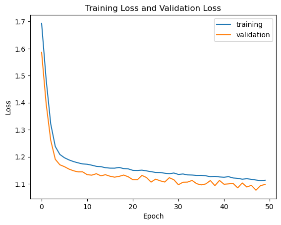

```python
# Capturing learning history per epoch
h = pd.DataFrame(history.history)
h['epoch'] = history.epoch
plt.xlabel('Epoch')
plt.ylabel('Loss')
plt.title("Training Loss and Validation Loss")
plt.plot(h['loss'])
plt.plot(h['val_loss'])
plt.legend(("training" , "validation") , loc =0);
```

- Training loss is higher than validation loss, it indicates model is not good

#### ii. Training Accuracy and Validation Accuracy

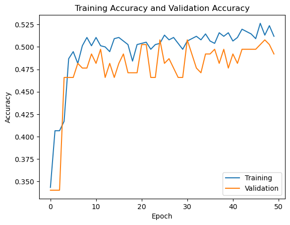

```python
plt.title("Training Accuracy and Validation Accuracy")
plt.plot(h['accuracy'])
plt.plot(h['val_accuracy'])
plt.xlabel('Epoch')
plt.ylabel('Accuracy')
plt.legend(("Training" , "Validation") , loc =0);
```

- Training accuracy is 49% where as Validation accuracy is 48%, It is an underfit model as the accuracy is not good either on training or validation.

```python
#test the model
Y_pred = model.predict(X_test)
results = model.evaluate(X_test, Y_test)
```

```
13/13 ━━━━━━━━━━━━━━━━━━━━ 0s 6ms/step
13/13 ━━━━━━━━━━━━━━━━━━━━ 0s 3ms/step - accuracy: 0.5014 - loss: 1.1616
```

Only 50% accuracy on test data, which is not good. It is a bad model.

#### D. Design new architecture/update existing architecture in attempt to improve the performance of the model. [2 Marks]

```python
model_1 = Sequential([
    Dense(64, input_shape=(11,), activation='relu'),
    Dropout(0.2),
    Dense(32, activation='relu'),
    Dropout(0.2),
    Dense(6, activation='softmax')
])

optimizer = optimizers.Adam(learning_rate=0.001)
model_1.compile(optimizer=optimizer, loss='categorical_crossentropy', metrics=['accuracy'])

history_1 = model_1.fit(X_train, Y_train, epochs=100, batch_size=16, validation_split=0.2) #training the model with increased number of epochs and smaller batch size
```

```
48/48 ━━━━━━━━━━━━━━━━━━━━ 2s 6ms/step - accuracy: 0.2273 - loss: 1.7359 - val_accuracy: 0.4869 - val_loss: 1.4418
48/48 ━━━━━━━━━━━━━━━━━━━━ 0s 2ms/step - accuracy: 0.4388 - loss: 1.3831 - val_accuracy: 0.4660 - val_loss: 1.2157
48/48 ━━━━━━━━━━━━━━━━━━━━ 0s 2ms/step - accuracy: 0.4283 - loss: 1.2954 - val_accuracy: 0.4555 - val_loss: 1.1820
48/48 ━━━━━━━━━━━━━━━━━━━━ 0s 3ms/step - accuracy: 0.4324 - loss: 1.2060 - val_accuracy: 0.4555 - val_loss: 1.1544
48/48 ━━━━━━━━━━━━━━━━━━━━ 0s 5ms/step - accuracy: 0.4682 - loss: 1.1891 - val_accuracy: 0.4555 - val_loss: 1.1448
48/48 ━━━━━━━━━━━━━━━━━━━━ 0s 2ms/step - accuracy: 0.4596 - loss: 1.1745 - val_accuracy: 0.4817 - val_loss: 1.1387
48/48 ━━━━━━━━━━━━━━━━━━━━ 0s 2ms/step - accuracy: 0.5037 - loss: 1.1850 - val_accuracy: 0.4764 - val_loss: 1.1463
48/48 ━━━━━━━━━━━━━━━━━━━━ 0s 2ms/step - accuracy: 0.4910 - loss: 1.2027 - val_accuracy: 0.4869 - val_loss: 1.1342
48/48 ━━━━━━━━━━━━━━━━━━━━ 0s 4ms/step - accuracy: 0.4333 - loss: 1.2503 - val_accuracy: 0.4869 - val_loss: 1.1317
48/48 ━━━━━━━━━━━━━━━━━━━━ 0s 3ms/step - accuracy: 0.4900 - loss: 1.1598 - val_accuracy: 0.4817 - val_loss: 1.1375
48/48 ━━━━━━━━━━━━━━━━━━━━ 0s 3ms/step - accuracy: 0.4792 - loss: 1.1679 - val_accuracy: 0.4712 - val_loss: 1.1372
48/48 ━━━━━━━━━━━━━━━━━━━━ 0s 5ms/step - accuracy: 0.5063 - loss: 1.1480 - val_accuracy: 0.4869 - val_loss: 1.1272
48/48 ━━━━━━━━━━━━━━━━━━━━ 0s 3ms/step - accuracy: 0.4911 - loss: 1.1357 - val_accuracy: 0.4712 - val_loss: 1.1328
48/48 ━━━━━━━━━━━━━━━━━━━━ 0s 2ms/step - accuracy: 0.4886 - loss: 1.1879 - val_accuracy: 0.4660 - val_loss: 1.1415
48/48 ━━━━━━━━━━━━━━━━━━━━ 0s 3ms/step - accuracy: 0.5063 - loss: 1.1449 - val_accuracy: 0.4712 - val_loss: 1.1363
48/48 ━━━━━━━━━━━━━━━━━━━━ 0s 2ms/step - accuracy: 0.5359 - loss: 1.1427 - val_accuracy: 0.4817 - val_loss: 1.1153
48/48 ━━━━━━━━━━━━━━━━━━━━ 0s 3ms/step - accuracy: 0.4893 - loss: 1.1609 - val_accuracy: 0.4921 - val_loss: 1.1173
48/48 ━━━━━━━━━━━━━━━━━━━━ 0s 3ms/step - accuracy: 0.4763 - loss: 1.1553 - val_accuracy: 0.4764 - val_loss: 1.1275
48/48 ━━━━━━━━━━━━━━━━━━━━ 0s 3ms/step - accuracy: 0.4773 - loss: 1.1605 - val_accuracy: 0.4712 - val_loss: 1.1346
48/48 ━━━━━━━━━━━━━━━━━━━━ 0s 2ms/step - accuracy: 0.4829 - loss: 1.1988 - val_accuracy: 0.4660 - val_loss: 1.1206
48/48 ━━━━━━━━━━━━━━━━━━━━ 0s 2ms/step - accuracy: 0.4801 - loss: 1.1786 - val_accuracy: 0.4764 - val_loss: 1.1127
48/48 ━━━━━━━━━━━━━━━━━━━━ 0s 2ms/step - accuracy: 0.5272 - loss: 1.1442 - val_accuracy: 0.4712 - val_loss: 1.1302
48/48 ━━━━━━━━━━━━━━━━━━━━ 0s 3ms/step - accuracy: 0.5215 - loss: 1.1646 - val_accuracy: 0.4764 - val_loss: 1.1267
48/48 ━━━━━━━━━━━━━━━━━━━━ 0s 2ms/step - accuracy: 0.4884 - loss: 1.2184 - val_accuracy: 0.4764 - val_loss: 1.1243
48/48 ━━━━━━━━━━━━━━━━━━━━ 0s 2ms/step - accuracy: 0.4985 - loss: 1.1818 - val_accuracy: 0.4712 - val_loss: 1.1232
48/48 ━━━━━━━━━━━━━━━━━━━━ 0s 3ms/step - accuracy: 0.5124 - loss: 1.1887 - val_accuracy: 0.4869 - val_loss: 1.1072
48/48 ━━━━━━━━━━━━━━━━━━━━ 0s 2ms/step - accuracy: 0.4990 - loss: 1.1507 - val_accuracy: 0.4660 - val_loss: 1.1300
48/48 ━━━━━━━━━━━━━━━━━━━━ 0s 2ms/step - accuracy: 0.4794 - loss: 1.1471 - val_accuracy: 0.4764 - val_loss: 1.1093
48/48 ━━━━━━━━━━━━━━━━━━━━ 0s 2ms/step - accuracy: 0.4649 - loss: 1.2075 - val_accuracy: 0.4712 - val_loss: 1.1246
48/48 ━━━━━━━━━━━━━━━━━━━━ 0s 2ms/step - accuracy: 0.4892 - loss: 1.1804 - val_accuracy: 0.4712 - val_loss: 1.1196
48/48 ━━━━━━━━━━━━━━━━━━━━ 0s 2ms/step - accuracy: 0.5340 - loss: 1.1057 - val_accuracy: 0.4817 - val_loss: 1.1063
48/48 ━━━━━━━━━━━━━━━━━━━━ 0s 3ms/step - accuracy: 0.4930 - loss: 1.1733 - val_accuracy: 0.4712 - val_loss: 1.1092
48/48 ━━━━━━━━━━━━━━━━━━━━ 0s 5ms/step - accuracy: 0.5030 - loss: 1.1660 - val_accuracy: 0.4660 - val_loss: 1.1257
48/48 ━━━━━━━━━━━━━━━━━━━━ 0s 2ms/step - accuracy: 0.4796 - loss: 1.1494 - val_accuracy: 0.4712 - val_loss: 1.1096
48/48 ━━━━━━━━━━━━━━━━━━━━ 0s 2ms/step - accuracy: 0.4873 - loss: 1.1753 - val_accuracy: 0.5131 - val_loss: 1.1006
48/48 ━━━━━━━━━━━━━━━━━━━━ 0s 2ms/step - accuracy: 0.4799 - loss: 1.1576 - val_accuracy: 0.4712 - val_loss: 1.1198
48/48 ━━━━━━━━━━━━━━━━━━━━ 0s 2ms/step - accuracy: 0.5193 - loss: 1.1368 - val_accuracy: 0.4764 - val_loss: 1.1129
48/48 ━━━━━━━━━━━━━━━━━━━━ 0s 3ms/step - accuracy: 0.4964 - loss: 1.1200 - val_accuracy: 0.4712 - val_loss: 1.1263
48/48 ━━━━━━━━━━━━━━━━━━━━ 0s 2ms/step - accuracy: 0.4986 - loss: 1.1379 - val_accuracy: 0.5131 - val_loss: 1.0976
48/48 ━━━━━━━━━━━━━━━━━━━━ 0s 2ms/step - accuracy: 0.5491 - loss: 1.0756 - val_accuracy: 0.4764 - val_loss: 1.1024
```

[output cut: 45 more lines]

```
48/48 ━━━━━━━━━━━━━━━━━━━━ 0s 5ms/step - accuracy: 0.5454 - loss: 1.1089 - val_accuracy: 0.5445 - val_loss: 1.0489
48/48 ━━━━━━━━━━━━━━━━━━━━ 0s 3ms/step - accuracy: 0.5287 - loss: 1.0740 - val_accuracy: 0.5445 - val_loss: 1.0444
48/48 ━━━━━━━━━━━━━━━━━━━━ 0s 2ms/step - accuracy: 0.5643 - loss: 1.0375 - val_accuracy: 0.5602 - val_loss: 1.0421
48/48 ━━━━━━━━━━━━━━━━━━━━ 0s 2ms/step - accuracy: 0.5175 - loss: 1.0952 - val_accuracy: 0.5393 - val_loss: 1.0446
48/48 ━━━━━━━━━━━━━━━━━━━━ 0s 2ms/step - accuracy: 0.5552 - loss: 1.0874 - val_accuracy: 0.5288 - val_loss: 1.0441
48/48 ━━━━━━━━━━━━━━━━━━━━ 0s 2ms/step - accuracy: 0.5569 - loss: 1.0903 - val_accuracy: 0.5602 - val_loss: 1.0396
48/48 ━━━━━━━━━━━━━━━━━━━━ 0s 3ms/step - accuracy: 0.5688 - loss: 1.0734 - val_accuracy: 0.5445 - val_loss: 1.0444
48/48 ━━━━━━━━━━━━━━━━━━━━ 0s 3ms/step - accuracy: 0.5297 - loss: 1.1090 - val_accuracy: 0.5288 - val_loss: 1.0514
48/48 ━━━━━━━━━━━━━━━━━━━━ 0s 2ms/step - accuracy: 0.5612 - loss: 1.0820 - val_accuracy: 0.5445 - val_loss: 1.0347
48/48 ━━━━━━━━━━━━━━━━━━━━ 0s 4ms/step - accuracy: 0.5520 - loss: 1.0559 - val_accuracy: 0.5445 - val_loss: 1.0355
48/48 ━━━━━━━━━━━━━━━━━━━━ 0s 2ms/step - accuracy: 0.5686 - loss: 1.0186 - val_accuracy: 0.5445 - val_loss: 1.0497
48/48 ━━━━━━━━━━━━━━━━━━━━ 0s 2ms/step - accuracy: 0.5407 - loss: 1.0803 - val_accuracy: 0.5602 - val_loss: 1.0717
48/48 ━━━━━━━━━━━━━━━━━━━━ 0s 2ms/step - accuracy: 0.5247 - loss: 1.0786 - val_accuracy: 0.5340 - val_loss: 1.0329
48/48 ━━━━━━━━━━━━━━━━━━━━ 0s 3ms/step - accuracy: 0.5352 - loss: 1.0594 - val_accuracy: 0.5393 - val_loss: 1.0346
48/48 ━━━━━━━━━━━━━━━━━━━━ 0s 3ms/step - accuracy: 0.5767 - loss: 1.0392 - val_accuracy: 0.5288 - val_loss: 1.0342
```

```python
Y_pred_1 = model_1.predict(X_test)
results_1 = model_1.evaluate(X_test, Y_test)
```

```
13/13 ━━━━━━━━━━━━━━━━━━━━ 0s 4ms/step
13/13 ━━━━━━━━━━━━━━━━━━━━ 0s 2ms/step - accuracy: 0.5189 - loss: 1.1076
```

**Model 2:** Adding batch normalization to the previous model, let us see the performance

```python
model_2 = Sequential([
    Dense(64, input_shape=(11,), activation='relu'),
    BatchNormalization(),
    Dropout(0.2),
    Dense(32, activation='relu'),
    BatchNormalization(),
    Dropout(0.2),
    Dense(6, activation='softmax')
])

optimizer = optimizers.Adam(learning_rate=0.001)
model_2.compile(optimizer=optimizer, loss='categorical_crossentropy', metrics=['accuracy'])

history_2 = model_2.fit(X_train, Y_train, epochs=100, batch_size=16, validation_split=0.2)
```

```
48/48 ━━━━━━━━━━━━━━━━━━━━ 2s 8ms/step - accuracy: 0.1782 - loss: 2.4383 - val_accuracy: 0.4921 - val_loss: 1.5923
48/48 ━━━━━━━━━━━━━━━━━━━━ 0s 3ms/step - accuracy: 0.3290 - loss: 1.9141 - val_accuracy: 0.4921 - val_loss: 1.4870
48/48 ━━━━━━━━━━━━━━━━━━━━ 0s 3ms/step - accuracy: 0.3893 - loss: 1.6906 - val_accuracy: 0.4921 - val_loss: 1.4039
48/48 ━━━━━━━━━━━━━━━━━━━━ 0s 3ms/step - accuracy: 0.3991 - loss: 1.5771 - val_accuracy: 0.5183 - val_loss: 1.3274
48/48 ━━━━━━━━━━━━━━━━━━━━ 0s 3ms/step - accuracy: 0.4837 - loss: 1.4768 - val_accuracy: 0.5393 - val_loss: 1.2796
48/48 ━━━━━━━━━━━━━━━━━━━━ 0s 2ms/step - accuracy: 0.4414 - loss: 1.4275 - val_accuracy: 0.5131 - val_loss: 1.2290
48/48 ━━━━━━━━━━━━━━━━━━━━ 0s 3ms/step - accuracy: 0.4909 - loss: 1.3173 - val_accuracy: 0.5026 - val_loss: 1.1982
48/48 ━━━━━━━━━━━━━━━━━━━━ 0s 2ms/step - accuracy: 0.4939 - loss: 1.2639 - val_accuracy: 0.5340 - val_loss: 1.1717
48/48 ━━━━━━━━━━━━━━━━━━━━ 0s 3ms/step - accuracy: 0.4447 - loss: 1.2743 - val_accuracy: 0.5026 - val_loss: 1.1423
48/48 ━━━━━━━━━━━━━━━━━━━━ 0s 2ms/step - accuracy: 0.4746 - loss: 1.2515 - val_accuracy: 0.4921 - val_loss: 1.1217
48/48 ━━━━━━━━━━━━━━━━━━━━ 0s 3ms/step - accuracy: 0.4744 - loss: 1.2639 - val_accuracy: 0.5183 - val_loss: 1.0955
48/48 ━━━━━━━━━━━━━━━━━━━━ 0s 2ms/step - accuracy: 0.4830 - loss: 1.2390 - val_accuracy: 0.5131 - val_loss: 1.0979
48/48 ━━━━━━━━━━━━━━━━━━━━ 0s 2ms/step - accuracy: 0.4954 - loss: 1.2362 - val_accuracy: 0.5497 - val_loss: 1.0870
48/48 ━━━━━━━━━━━━━━━━━━━━ 0s 2ms/step - accuracy: 0.5270 - loss: 1.1256 - val_accuracy: 0.5602 - val_loss: 1.0802
48/48 ━━━━━━━━━━━━━━━━━━━━ 0s 3ms/step - accuracy: 0.4878 - loss: 1.1810 - val_accuracy: 0.5340 - val_loss: 1.0751
48/48 ━━━━━━━━━━━━━━━━━━━━ 0s 2ms/step - accuracy: 0.5243 - loss: 1.1581 - val_accuracy: 0.5654 - val_loss: 1.0569
48/48 ━━━━━━━━━━━━━━━━━━━━ 0s 5ms/step - accuracy: 0.4789 - loss: 1.1549 - val_accuracy: 0.5759 - val_loss: 1.0441
48/48 ━━━━━━━━━━━━━━━━━━━━ 0s 3ms/step - accuracy: 0.5246 - loss: 1.1523 - val_accuracy: 0.5812 - val_loss: 1.0542
48/48 ━━━━━━━━━━━━━━━━━━━━ 0s 3ms/step - accuracy: 0.5462 - loss: 1.1068 - val_accuracy: 0.5445 - val_loss: 1.0719
48/48 ━━━━━━━━━━━━━━━━━━━━ 0s 3ms/step - accuracy: 0.5169 - loss: 1.0941 - val_accuracy: 0.6021 - val_loss: 1.0345
48/48 ━━━━━━━━━━━━━━━━━━━━ 0s 2ms/step - accuracy: 0.5290 - loss: 1.0862 - val_accuracy: 0.5602 - val_loss: 1.0564
48/48 ━━━━━━━━━━━━━━━━━━━━ 0s 3ms/step - accuracy: 0.5437 - loss: 1.0931 - val_accuracy: 0.5707 - val_loss: 1.0556
48/48 ━━━━━━━━━━━━━━━━━━━━ 0s 3ms/step - accuracy: 0.5439 - loss: 1.0524 - val_accuracy: 0.5550 - val_loss: 1.0548
48/48 ━━━━━━━━━━━━━━━━━━━━ 0s 3ms/step - accuracy: 0.5200 - loss: 1.1459 - val_accuracy: 0.5707 - val_loss: 1.0457
48/48 ━━━━━━━━━━━━━━━━━━━━ 0s 3ms/step - accuracy: 0.5393 - loss: 1.1063 - val_accuracy: 0.5497 - val_loss: 1.0133
48/48 ━━━━━━━━━━━━━━━━━━━━ 0s 3ms/step - accuracy: 0.5130 - loss: 1.0809 - val_accuracy: 0.5759 - val_loss: 0.9998
48/48 ━━━━━━━━━━━━━━━━━━━━ 0s 3ms/step - accuracy: 0.5261 - loss: 1.0318 - val_accuracy: 0.5654 - val_loss: 1.0156
48/48 ━━━━━━━━━━━━━━━━━━━━ 0s 3ms/step - accuracy: 0.5611 - loss: 1.0688 - val_accuracy: 0.5654 - val_loss: 0.9958
48/48 ━━━━━━━━━━━━━━━━━━━━ 0s 2ms/step - accuracy: 0.5666 - loss: 1.0122 - val_accuracy: 0.5340 - val_loss: 1.0217
48/48 ━━━━━━━━━━━━━━━━━━━━ 0s 3ms/step - accuracy: 0.5515 - loss: 1.0534 - val_accuracy: 0.5864 - val_loss: 1.0146
48/48 ━━━━━━━━━━━━━━━━━━━━ 0s 2ms/step - accuracy: 0.5702 - loss: 1.0575 - val_accuracy: 0.6021 - val_loss: 0.9921
48/48 ━━━━━━━━━━━━━━━━━━━━ 0s 3ms/step - accuracy: 0.5437 - loss: 1.0786 - val_accuracy: 0.5864 - val_loss: 1.0321
48/48 ━━━━━━━━━━━━━━━━━━━━ 0s 3ms/step - accuracy: 0.5397 - loss: 1.0599 - val_accuracy: 0.5864 - val_loss: 1.0654
48/48 ━━━━━━━━━━━━━━━━━━━━ 0s 2ms/step - accuracy: 0.5389 - loss: 1.0746 - val_accuracy: 0.5654 - val_loss: 1.0713
48/48 ━━━━━━━━━━━━━━━━━━━━ 0s 3ms/step - accuracy: 0.5712 - loss: 1.0153 - val_accuracy: 0.5654 - val_loss: 1.0564
48/48 ━━━━━━━━━━━━━━━━━━━━ 0s 3ms/step - accuracy: 0.5595 - loss: 1.0095 - val_accuracy: 0.5602 - val_loss: 1.1131
48/48 ━━━━━━━━━━━━━━━━━━━━ 0s 3ms/step - accuracy: 0.5492 - loss: 1.0168 - val_accuracy: 0.4450 - val_loss: 1.2375
48/48 ━━━━━━━━━━━━━━━━━━━━ 0s 4ms/step - accuracy: 0.5740 - loss: 1.0135 - val_accuracy: 0.5445 - val_loss: 1.1404
48/48 ━━━━━━━━━━━━━━━━━━━━ 0s 3ms/step - accuracy: 0.5671 - loss: 1.0305 - val_accuracy: 0.6126 - val_loss: 1.0032
48/48 ━━━━━━━━━━━━━━━━━━━━ 0s 3ms/step - accuracy: 0.5759 - loss: 1.0085 - val_accuracy: 0.5864 - val_loss: 0.9959
```

[output cut: 45 more lines]

```
48/48 ━━━━━━━━━━━━━━━━━━━━ 0s 4ms/step - accuracy: 0.5327 - loss: 1.0488 - val_accuracy: 0.5707 - val_loss: 1.0692
48/48 ━━━━━━━━━━━━━━━━━━━━ 0s 3ms/step - accuracy: 0.6061 - loss: 0.9192 - val_accuracy: 0.5969 - val_loss: 1.0031
48/48 ━━━━━━━━━━━━━━━━━━━━ 0s 3ms/step - accuracy: 0.5824 - loss: 0.9726 - val_accuracy: 0.6283 - val_loss: 1.0063
48/48 ━━━━━━━━━━━━━━━━━━━━ 0s 2ms/step - accuracy: 0.5872 - loss: 0.9673 - val_accuracy: 0.6178 - val_loss: 1.0022
48/48 ━━━━━━━━━━━━━━━━━━━━ 0s 3ms/step - accuracy: 0.5716 - loss: 0.9971 - val_accuracy: 0.6230 - val_loss: 0.9851
48/48 ━━━━━━━━━━━━━━━━━━━━ 0s 3ms/step - accuracy: 0.5638 - loss: 0.9542 - val_accuracy: 0.5969 - val_loss: 1.0315
48/48 ━━━━━━━━━━━━━━━━━━━━ 0s 3ms/step - accuracy: 0.5848 - loss: 0.9818 - val_accuracy: 0.6283 - val_loss: 1.0109
48/48 ━━━━━━━━━━━━━━━━━━━━ 0s 3ms/step - accuracy: 0.5693 - loss: 0.9992 - val_accuracy: 0.6387 - val_loss: 0.9393
48/48 ━━━━━━━━━━━━━━━━━━━━ 0s 6ms/step - accuracy: 0.5606 - loss: 0.9728 - val_accuracy: 0.6545 - val_loss: 0.9431
48/48 ━━━━━━━━━━━━━━━━━━━━ 0s 3ms/step - accuracy: 0.5916 - loss: 0.9579 - val_accuracy: 0.6387 - val_loss: 0.9351
48/48 ━━━━━━━━━━━━━━━━━━━━ 0s 3ms/step - accuracy: 0.5622 - loss: 0.9762 - val_accuracy: 0.6387 - val_loss: 0.9816
48/48 ━━━━━━━━━━━━━━━━━━━━ 0s 3ms/step - accuracy: 0.5730 - loss: 0.9894 - val_accuracy: 0.6440 - val_loss: 0.9476
48/48 ━━━━━━━━━━━━━━━━━━━━ 0s 3ms/step - accuracy: 0.5591 - loss: 0.9670 - val_accuracy: 0.6335 - val_loss: 0.9902
48/48 ━━━━━━━━━━━━━━━━━━━━ 0s 4ms/step - accuracy: 0.5637 - loss: 0.9489 - val_accuracy: 0.6597 - val_loss: 0.9536
48/48 ━━━━━━━━━━━━━━━━━━━━ 0s 3ms/step - accuracy: 0.5853 - loss: 0.9825 - val_accuracy: 0.6283 - val_loss: 0.9619
```

```python
Y_pred_2 = model_2.predict(X_test)
results_2 = model_2.evaluate(X_test, Y_test)
```

```
13/13 ━━━━━━━━━━━━━━━━━━━━ 0s 8ms/step
13/13 ━━━━━━━━━━━━━━━━━━━━ 0s 1ms/step - accuracy: 0.5304 - loss: 1.0565
```

- This model is also not very good model as train accuracy 59%, validation accuracy is 62.3% and test accuracy is 53%, which is better than previous model but not the best model. Overall accuracy score is very less.

#### E. Plot visuals as in Q3.C and share insights about difference observed in both the models. [3 Marks]

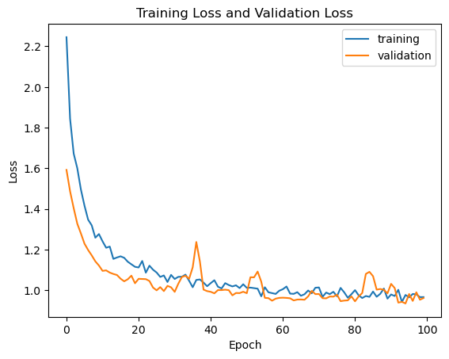

```python
# Capturing learning history per epoch
h_2 = pd.DataFrame(history_2.history)
h_2['epoch'] = history_2.epoch
plt.xlabel('Epoch')
plt.ylabel('Loss')
plt.title("Training Loss and Validation Loss")
plt.plot(h_2['loss'])
plt.plot(h_2['val_loss'])
plt.legend(("training" , "validation") , loc =0);
```

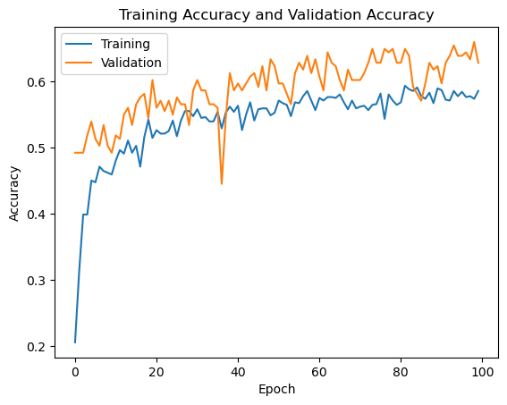

```python
plt.title("Training Accuracy and Validation Accuracy")
plt.plot(h_2['accuracy'])
plt.plot(h_2['val_accuracy'])
plt.xlabel('Epoch')
plt.ylabel('Accuracy')
plt.legend(("Training" , "Validation"), loc =0);
```

#### Part B - 30 Marks

**• DOMAIN:** Autonomous Vehicles  
**• CONTEXT:** A Recognising multi-digit numbers in photographs captured at street level is an important component of modern-day map making. A classic example of a corpus of such street-level photographs is Google’s Street View imagery composed of hundreds of millions of geo-located 360-degree panoramic images.

The ability to automatically transcribe an address number from a geo-located patch of pixels and associate the transcribed number with a known street address helps pinpoint, with a high degree of accuracy, the location of the building it represents. More broadly, recognising numbers in photographs is a problem of interest to the optical character recognition community.

While OCR on constrained domains like document processing is well studied, arbitrary multi-character text recognition in photographs is still highly challenging. This difficulty arises due to the wide variability in the visual appearance of text in the wild on account of a large range of fonts, colours, styles, orientations, and character arrangements.

The recognition problem is further complicated by environmental factors such as lighting, shadows, specularity, and occlusions as well as by image acquisition factors such as resolution, motion, and focus blurs. In this project, we will use the dataset with images centred around a single digit (many of the images do contain some distractors at the sides). Although we are taking a sample of the data which is simpler, it is more complex than MNIST because of the distractors.

**• DATA DESCRIPTION:** The SVHN is a real-world image dataset for developing machine learning and object recognition algorithms with the minimal requirement on data formatting but comes from a significantly harder, unsolved, real-world problem (recognising digits and numbers in natural scene images). SVHN is obtained from house numbers in Google Street View images.

**• PROJECT OBJECTIVE:** To build a digit classifier on the SVHN (Street View Housing Number) dataset.

#### Steps and tasks:[ Total Score: 30 Marks]

#### 1. Data Import and Exploration [5 Marks]

#### A. Read the .h5 file and assign to a variable. [2 Marks]

```python
import h5py
file = h5py.File('Autonomous_Vehicles_SVHN_single_grey1.h5', 'r') #open the file in read mode
vehicle_df = dict(file) #assign the content to a variable
vehicle_df
```

```
{'X_test': <HDF5 dataset "X_test": shape (18000, 32, 32), type "<f4">,
 'X_train': <HDF5 dataset "X_train": shape (42000, 32, 32), type "<f4">,
 'X_val': <HDF5 dataset "X_val": shape (60000, 32, 32), type "<f4">,
 'y_test': <HDF5 dataset "y_test": shape (18000,), type "|u1">,
 'y_train': <HDF5 dataset "y_train": shape (42000,), type "|u1">,
 'y_val': <HDF5 dataset "y_val": shape (60000,), type "|u1">}
```

#### B. Print all the keys from the .h5 file. [1 Marks]

```python
list(vehicle_df.keys())
```

```
['X_test', 'X_train', 'X_val', 'y_test', 'y_train', 'y_val']
```

#### C. Split the data into X_train, X_test, Y_train, Y_test [2 Marks]

```python
X_train = vehicle_df['X_train'][:]
X_test = vehicle_df['X_test'][:]
X_val = vehicle_df['X_val'][:]
Y_train = vehicle_df['y_train'][:]
Y_test = vehicle_df['y_test'][:]
Y_val = vehicle_df['y_val'][:]
```

#### 2. Data Visualisation and preprocessing [13 Marks]

#### A. Print shape of all the 4 data split into x, y, train, test to verify if x & y is in sync. [1 Marks]

```python
print("shape of X_train:",X_train.shape)
print("shape of X_val:",X_val.shape)
print("shape of X_test:",X_test.shape)

print("shape of Y_train:",Y_train.shape)
print("shape of Y_val:",Y_val.shape)
print("shape of Y_test:",Y_test.shape)
```

```
shape of X_train: (42000, 32, 32)
shape of X_val: (60000, 32, 32)
shape of X_test: (18000, 32, 32)
shape of Y_train: (42000,)
shape of Y_val: (60000,)
shape of Y_test: (18000,)
```

- The number of rows in X_train and Y_train is same(42000), number of rows in X_val and Y_val is also same(60000) and number of rows in X_test and Y_test is also same(18000). so yes, they are all in sync.

#### B. Visualise first 10 images in train data and print its corresponding labels. [4 Marks]

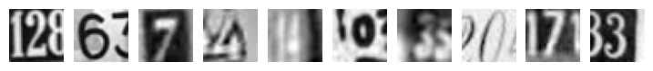

```
label for each of the above image: [2 6 7 4 4 0 3 0 7 3]
```

```python
plt.figure(figsize=(9, 2))
for i in range(10):
    plt.subplot(1, 10, i+1)
    plt.imshow(X_train[i], cmap="gray")
    plt.axis('off')
plt.show()
print('label for each of the above image: %s' % (Y_train[0:10]))
```

#### C. Reshape all the images with appropriate shape update the data in same variable. [3 Marks]

#### AND

#### D. Normalise the images i.e. Normalise the pixel values. [2 Marks]

```python
# We will reshape all the images to flatten it
img_vector_size = 32*32

X_train = np.array(X_train)
X_test = np.array(X_test)
X_val = np.array(X_val)

X_train = X_train.reshape(X_train.shape[0], img_vector_size)
X_test = X_test.reshape(X_test.shape[0], img_vector_size)
X_val = X_val.reshape(X_val.shape[0], img_vector_size)

# normalize inputs from 0-255 to 0-1
X_train = X_train / 255
X_test = X_test / 255
X_val = X_val / 255

print('Training set', X_train.shape, Y_train.shape)
print('Test set', X_test.shape, Y_test.shape)
print('Validation set', X_val.shape, Y_val.shape)
```

```
Training set (42000, 1024) (42000,)
Test set (18000, 1024) (18000,)
Validation set (60000, 1024) (60000,)
```

#### E. Transform Labels into format acceptable by Neural Network [2 Marks]

#### AND

#### F. Print total Number of classes in the Dataset. [1 Marks]

```python
np.unique(Y_train)
```

```
array([0, 1, 2, 3, 4, 5, 6, 7, 8, 9], dtype=uint8)
```

```python
np.unique(Y_test)
```

```
array([0, 1, 2, 3, 4, 5, 6, 7, 8, 9], dtype=uint8)
```

```python
np.unique(Y_val)
```

```
array([0, 1, 2, 3, 4, 5, 6, 7, 8, 9], dtype=uint8)
```

```python
print("Total number of unique classes in Y_train:", len(np.unique(Y_train)))
print("Total number of unique classes in Y_test:", len(np.unique(Y_test)))
print("Total number of unique classes in Y_val:", len(np.unique(Y_val)))
```

```
Total number of unique classes in Y_train: 10
Total number of unique classes in Y_test: 10
Total number of unique classes in Y_val: 10
```

```python
#preserve actual Y_test value for drawing perforamnce metrics
preserved_actual_Y_test = Y_test
```

```python
num_classes_count = 10 # 0, 1, 2, 3, 4, 5, 6, 7, 8, 9 total 10 classes in target variable Y train and test
#transformation into format accceptable by neural network
Y_train = to_categorical(Y_train, num_classes_count)
Y_test = to_categorical(Y_test,num_classes_count)
Y_val = to_categorical(Y_val,num_classes_count)
```

```python
print("First 5 training lables as one-hot encoded vectors:\n", Y_train[:5])
```

```
First 5 training lables as one-hot encoded vectors:
 [[0. 0. 1. 0. 0. 0. 0. 0. 0. 0.]
 [0. 0. 0. 0. 0. 0. 1. 0. 0. 0.]
 [0. 0. 0. 0. 0. 0. 0. 1. 0. 0.]
 [0. 0. 0. 0. 1. 0. 0. 0. 0. 0.]
 [0. 0. 0. 0. 1. 0. 0. 0. 0. 0.]]
```

```python
print("First 5 testing lables as one-hot encoded vectors:\n", Y_test[:5])
```

```
First 5 testing lables as one-hot encoded vectors:
 [[0. 1. 0. 0. 0. 0. 0. 0. 0. 0.]
 [0. 0. 0. 0. 0. 0. 0. 1. 0. 0.]
 [0. 0. 1. 0. 0. 0. 0. 0. 0. 0.]
 [0. 0. 0. 0. 0. 0. 0. 0. 0. 1.]
 [1. 0. 0. 0. 0. 0. 0. 0. 0. 0.]]
```

```python
print("First 5 validation lables as one-hot encoded vectors:\n", Y_val[:5])
```

```
First 5 validation lables as one-hot encoded vectors:
 [[1. 0. 0. 0. 0. 0. 0. 0. 0. 0.]
 [1. 0. 0. 0. 0. 0. 0. 0. 0. 0.]
 [1. 0. 0. 0. 0. 0. 0. 0. 0. 0.]
 [1. 0. 0. 0. 0. 0. 0. 0. 0. 0.]
 [1. 0. 0. 0. 0. 0. 0. 0. 0. 0.]]
```

#### 3. Model Training & Evaluation using Neural Network [12 Marks]

#### A. Design a Neural Network to train a classifier. [3 Marks]

#### AND

#### B. Train the classifier using previously designed Architecture (Use best suitable parameters). [3 Marks]

#### AND

#### C. Evaluate performance of the model with appropriate metrics. [2 Marks]

**Model with very slow learning rate 0.0001 and 10 epochs**

- We have used batch normalization, dropout reglurarization techniques and tried different number of hidden layers to make improved model. Also evaluated model with different number of hidden layers and unit counts in that and designed the neural network as below:

```python
image_size=32*32

model = Sequential()

model.add(Dense(512, activation='relu',kernel_initializer='he_uniform',input_shape=(image_size,)))
model.add(BatchNormalization())
model.add(Dense(256, activation='relu',kernel_initializer='he_uniform'))
model.add(Dense(256, activation='relu',kernel_initializer='he_uniform'))
model.add(Dropout(0.5))
model.add(Dense(128, activation='relu',kernel_initializer='he_uniform'))
model.add(Dense(128, activation='relu',kernel_initializer='he_uniform'))
model.add(Dropout(0.5))
model.add(Dense(64, activation='relu',kernel_initializer='he_uniform'))
model.add(Dense(64, activation='relu',kernel_initializer='he_uniform'))

model.add(Dense(num_classes_count, activation='softmax'))

adam = optimizers.Adam(learning_rate=0.0001)
model.compile(loss=tf.losses.categorical_crossentropy, optimizer=adam, metrics=['accuracy'])

model.summary()

checkpoint = ModelCheckpoint("model_weights.weights.h5",monitor='val_accuracy',
                          save_weights_only=True, mode='max',verbose=1)
reduce_learningrate = ReduceLROnPlateau(monitor='val_loss',factor=0.1,patience=2,min_lr=0.00001,model='auto')
callbacks = [checkpoint,reduce_learningrate]

history=model.fit(X_train, Y_train, validation_data=(X_val, Y_val), epochs=10, batch_size=512, verbose=2,callbacks=callbacks)
```

```
Model: "sequential_8"
```

```
┏━━━━━━━━━━━━━━━━━━━━━━━━━━━━━━━━━━━━━━┳━━━━━━━━━━━━━━━━━━━━━━━━━━━━━┳━━━━━━━━━━━━━━━━━┓
┃ Layer (type)                         ┃ Output Shape                ┃         Param # ┃
┡━━━━━━━━━━━━━━━━━━━━━━━━━━━━━━━━━━━━━━╇━━━━━━━━━━━━━━━━━━━━━━━━━━━━━╇━━━━━━━━━━━━━━━━━┩
│ dense_35 (Dense)                     │ (None, 512)                 │         524,800 │
├──────────────────────────────────────┼─────────────────────────────┼─────────────────┤
│ batch_normalization_5                │ (None, 512)                 │           2,048 │
│ (BatchNormalization)                 │                             │                 │
├──────────────────────────────────────┼─────────────────────────────┼─────────────────┤
│ dense_36 (Dense)                     │ (None, 256)                 │         131,328 │
├──────────────────────────────────────┼─────────────────────────────┼─────────────────┤
│ dense_37 (Dense)                     │ (None, 256)                 │          65,792 │
├──────────────────────────────────────┼─────────────────────────────┼─────────────────┤
│ dropout_12 (Dropout)                 │ (None, 256)                 │               0 │
├──────────────────────────────────────┼─────────────────────────────┼─────────────────┤
│ dense_38 (Dense)                     │ (None, 128)                 │          32,896 │
├──────────────────────────────────────┼─────────────────────────────┼─────────────────┤
│ dense_39 (Dense)                     │ (None, 128)                 │          16,512 │
├──────────────────────────────────────┼─────────────────────────────┼─────────────────┤
│ dropout_13 (Dropout)                 │ (None, 128)                 │               0 │
├──────────────────────────────────────┼─────────────────────────────┼─────────────────┤
│ dense_40 (Dense)                     │ (None, 64)                  │           8,256 │
├──────────────────────────────────────┼─────────────────────────────┼─────────────────┤
│ dense_41 (Dense)                     │ (None, 64)                  │           4,160 │
├──────────────────────────────────────┼─────────────────────────────┼─────────────────┤
│ dense_42 (Dense)                     │ (None, 10)                  │             650 │
└──────────────────────────────────────┴─────────────────────────────┴─────────────────┘
```

```
 Total params: 786,442 (3.00 MB)
```

```
 Trainable params: 785,418 (3.00 MB)
```

```
 Non-trainable params: 1,024 (4.00 KB)
```

```
Epoch 1: saving model to model_weights.weights.h5
83/83 - 7s - 80ms/step - accuracy: 0.1056 - loss: 2.6429 - val_accuracy: 0.1115 - val_loss: 2.2982 - learning_rate: 1.0000e-04

Epoch 2: saving model to model_weights.weights.h5
83/83 - 3s - 40ms/step - accuracy: 0.1081 - loss: 2.3514 - val_accuracy: 0.1264 - val_loss: 2.2952 - learning_rate: 1.0000e-04

Epoch 3: saving model to model_weights.weights.h5
83/83 - 4s - 43ms/step - accuracy: 0.1137 - loss: 2.3188 - val_accuracy: 0.1511 - val_loss: 2.2895 - learning_rate: 1.0000e-04

Epoch 4: saving model to model_weights.weights.h5
83/83 - 4s - 43ms/step - accuracy: 0.1246 - loss: 2.3020 - val_accuracy: 0.1708 - val_loss: 2.2782 - learning_rate: 1.0000e-04

Epoch 5: saving model to model_weights.weights.h5
83/83 - 4s - 48ms/step - accuracy: 0.1408 - loss: 2.2768 - val_accuracy: 0.1980 - val_loss: 2.2342 - learning_rate: 1.0000e-04

Epoch 6: saving model to model_weights.weights.h5
83/83 - 5s - 60ms/step - accuracy: 0.1715 - loss: 2.2260 - val_accuracy: 0.2426 - val_loss: 2.1423 - learning_rate: 1.0000e-04

Epoch 7: saving model to model_weights.weights.h5
83/83 - 5s - 56ms/step - accuracy: 0.2226 - loss: 2.1212 - val_accuracy: 0.3302 - val_loss: 1.9691 - learning_rate: 1.0000e-04

Epoch 8: saving model to model_weights.weights.h5
83/83 - 4s - 46ms/step - accuracy: 0.2774 - loss: 1.9926 - val_accuracy: 0.4112 - val_loss: 1.7949 - learning_rate: 1.0000e-04

Epoch 9: saving model to model_weights.weights.h5
83/83 - 4s - 42ms/step - accuracy: 0.3355 - loss: 1.8531 - val_accuracy: 0.4430 - val_loss: 1.6492 - learning_rate: 1.0000e-04

Epoch 10: saving model to model_weights.weights.h5
83/83 - 3s - 42ms/step - accuracy: 0.3844 - loss: 1.7268 - val_accuracy: 0.4854 - val_loss: 1.5565 - learning_rate: 1.0000e-04
```

```python
print("\nTraining score:", model.evaluate(X_train,Y_train))
print("\nValidation score", model.evaluate(X_val,Y_val))
print("\nTest score",model.evaluate(X_test,Y_test))
```

```
1313/1313 ━━━━━━━━━━━━━━━━━━━━ 3s 2ms/step - accuracy: 0.4862 - loss: 1.5538

Training score: [1.556473970413208, 0.48626190423965454]
1875/1875 ━━━━━━━━━━━━━━━━━━━━ 4s 2ms/step - accuracy: 0.4245 - loss: 1.6440

Validation score [1.5565310716629028, 0.48536667227745056]
563/563 ━━━━━━━━━━━━━━━━━━━━ 1s 2ms/step - accuracy: 0.4838 - loss: 1.5492

Test score [1.5566694736480713, 0.4832777678966522]
```

- Need improvement on this model like increase the learning rate and epochs.
- Loss is also high on training, validation and testing data
- Accuracy on train, validation and test data did not even cross 50%.

**Model with increased learning rate 0.001 and 50 epochs**

```python
image_size=32*32

model = Sequential()

model.add(Dense(512, activation='relu',kernel_initializer='he_uniform',input_shape=(image_size,)))
model.add(BatchNormalization())
model.add(Dense(256, activation='relu',kernel_initializer='he_uniform'))
model.add(Dense(256, activation='relu',kernel_initializer='he_uniform'))
model.add(Dropout(0.5))
model.add(Dense(128, activation='relu',kernel_initializer='he_uniform'))
model.add(Dense(128, activation='relu',kernel_initializer='he_uniform'))
model.add(Dropout(0.5))
model.add(Dense(64, activation='relu',kernel_initializer='he_uniform'))
model.add(Dense(64, activation='relu',kernel_initializer='he_uniform'))

model.add(Dense(num_classes_count, activation='softmax'))

adam = optimizers.Adam(learning_rate=0.001)
model.compile(loss=tf.losses.categorical_crossentropy, optimizer=adam, metrics=['accuracy'])

model.summary()

checkpoint = ModelCheckpoint("model_weights.weights.h5",monitor='val_accuracy',
                          save_weights_only=True, mode='max',verbose=1)
reduce_learningrate = ReduceLROnPlateau(monitor='val_loss',factor=0.1,patience=2,min_lr=0.00001,model='auto')
callbacks = [checkpoint,reduce_learningrate]

history=model.fit(X_train, Y_train, validation_data=(X_val, Y_val), epochs=50, batch_size=512, verbose=2,callbacks=callbacks)
```

```
Model: "sequential_9"
```

```
┏━━━━━━━━━━━━━━━━━━━━━━━━━━━━━━━━━━━━━━┳━━━━━━━━━━━━━━━━━━━━━━━━━━━━━┳━━━━━━━━━━━━━━━━━┓
┃ Layer (type)                         ┃ Output Shape                ┃         Param # ┃
┡━━━━━━━━━━━━━━━━━━━━━━━━━━━━━━━━━━━━━━╇━━━━━━━━━━━━━━━━━━━━━━━━━━━━━╇━━━━━━━━━━━━━━━━━┩
│ dense_43 (Dense)                     │ (None, 512)                 │         524,800 │
├──────────────────────────────────────┼─────────────────────────────┼─────────────────┤
│ batch_normalization_6                │ (None, 512)                 │           2,048 │
│ (BatchNormalization)                 │                             │                 │
├──────────────────────────────────────┼─────────────────────────────┼─────────────────┤
│ dense_44 (Dense)                     │ (None, 256)                 │         131,328 │
├──────────────────────────────────────┼─────────────────────────────┼─────────────────┤
│ dense_45 (Dense)                     │ (None, 256)                 │          65,792 │
├──────────────────────────────────────┼─────────────────────────────┼─────────────────┤
│ dropout_14 (Dropout)                 │ (None, 256)                 │               0 │
├──────────────────────────────────────┼─────────────────────────────┼─────────────────┤
│ dense_46 (Dense)                     │ (None, 128)                 │          32,896 │
├──────────────────────────────────────┼─────────────────────────────┼─────────────────┤
│ dense_47 (Dense)                     │ (None, 128)                 │          16,512 │
├──────────────────────────────────────┼─────────────────────────────┼─────────────────┤
│ dropout_15 (Dropout)                 │ (None, 128)                 │               0 │
├──────────────────────────────────────┼─────────────────────────────┼─────────────────┤
│ dense_48 (Dense)                     │ (None, 64)                  │           8,256 │
├──────────────────────────────────────┼─────────────────────────────┼─────────────────┤
│ dense_49 (Dense)                     │ (None, 64)                  │           4,160 │
├──────────────────────────────────────┼─────────────────────────────┼─────────────────┤
│ dense_50 (Dense)                     │ (None, 10)                  │             650 │
└──────────────────────────────────────┴─────────────────────────────┴─────────────────┘
```

```
 Total params: 786,442 (3.00 MB)
```

```
 Trainable params: 785,418 (3.00 MB)
```

```
 Non-trainable params: 1,024 (4.00 KB)
```

```
Epoch 1: saving model to model_weights.weights.h5
83/83 - 7s - 82ms/step - accuracy: 0.1057 - loss: 2.3550 - val_accuracy: 0.1025 - val_loss: 2.3045 - learning_rate: 0.0010

Epoch 2: saving model to model_weights.weights.h5
83/83 - 4s - 43ms/step - accuracy: 0.1156 - loss: 2.2980 - val_accuracy: 0.1690 - val_loss: 2.2654 - learning_rate: 0.0010

Epoch 3: saving model to model_weights.weights.h5
83/83 - 4s - 48ms/step - accuracy: 0.2315 - loss: 2.0420 - val_accuracy: 0.2412 - val_loss: 2.0966 - learning_rate: 0.0010

Epoch 4: saving model to model_weights.weights.h5
83/83 - 4s - 45ms/step - accuracy: 0.4249 - loss: 1.5946 - val_accuracy: 0.2832 - val_loss: 2.0385 - learning_rate: 0.0010

Epoch 5: saving model to model_weights.weights.h5
83/83 - 4s - 45ms/step - accuracy: 0.5218 - loss: 1.3768 - val_accuracy: 0.3653 - val_loss: 1.7957 - learning_rate: 0.0010

Epoch 6: saving model to model_weights.weights.h5
83/83 - 4s - 47ms/step - accuracy: 0.5778 - loss: 1.2550 - val_accuracy: 0.4620 - val_loss: 1.5362 - learning_rate: 0.0010

Epoch 7: saving model to model_weights.weights.h5
83/83 - 3s - 42ms/step - accuracy: 0.6338 - loss: 1.1168 - val_accuracy: 0.3565 - val_loss: 2.0485 - learning_rate: 0.0010

Epoch 8: saving model to model_weights.weights.h5
83/83 - 4s - 46ms/step - accuracy: 0.6474 - loss: 1.0905 - val_accuracy: 0.3907 - val_loss: 1.9318 - learning_rate: 0.0010

Epoch 9: saving model to model_weights.weights.h5
83/83 - 4s - 43ms/step - accuracy: 0.6935 - loss: 0.9625 - val_accuracy: 0.6156 - val_loss: 1.1337 - learning_rate: 1.0000e-04

Epoch 10: saving model to model_weights.weights.h5
83/83 - 5s - 59ms/step - accuracy: 0.7079 - loss: 0.9230 - val_accuracy: 0.7034 - val_loss: 0.9201 - learning_rate: 1.0000e-04

Epoch 11: saving model to model_weights.weights.h5
83/83 - 4s - 45ms/step - accuracy: 0.7154 - loss: 0.9017 - val_accuracy: 0.7347 - val_loss: 0.8339 - learning_rate: 1.0000e-04

Epoch 12: saving model to model_weights.weights.h5
83/83 - 4s - 43ms/step - accuracy: 0.7226 - loss: 0.8902 - val_accuracy: 0.7508 - val_loss: 0.7966 - learning_rate: 1.0000e-04

Epoch 13: saving model to model_weights.weights.h5
83/83 - 4s - 45ms/step - accuracy: 0.7225 - loss: 0.8762 - val_accuracy: 0.7571 - val_loss: 0.7724 - learning_rate: 1.0000e-04

Epoch 14: saving model to model_weights.weights.h5
```

[output cut: 94 more lines]

```

Epoch 46: saving model to model_weights.weights.h5
83/83 - 4s - 48ms/step - accuracy: 0.7962 - loss: 0.6650 - val_accuracy: 0.8252 - val_loss: 0.5759 - learning_rate: 1.0000e-05

Epoch 47: saving model to model_weights.weights.h5
83/83 - 4s - 50ms/step - accuracy: 0.7963 - loss: 0.6645 - val_accuracy: 0.8253 - val_loss: 0.5752 - learning_rate: 1.0000e-05

Epoch 48: saving model to model_weights.weights.h5
83/83 - 4s - 46ms/step - accuracy: 0.7945 - loss: 0.6633 - val_accuracy: 0.8250 - val_loss: 0.5749 - learning_rate: 1.0000e-05

Epoch 49: saving model to model_weights.weights.h5
83/83 - 4s - 50ms/step - accuracy: 0.7976 - loss: 0.6606 - val_accuracy: 0.8260 - val_loss: 0.5742 - learning_rate: 1.0000e-05

Epoch 50: saving model to model_weights.weights.h5
83/83 - 4s - 46ms/step - accuracy: 0.7984 - loss: 0.6619 - val_accuracy: 0.8261 - val_loss: 0.5735 - learning_rate: 1.0000e-05
```

- After 50 iterations, We see 80% accuracy on training data and 83% accuracy on validation data.
- Loss is also comparatively less than previous model with less learning rate 0.0001 and 10 epochs

```python
print("\nTraining score:", model.evaluate(X_train,Y_train))
print("\nValidation score", model.evaluate(X_val,Y_val))
print("\nTest score",model.evaluate(X_test,Y_test))
```

```
1313/1313 ━━━━━━━━━━━━━━━━━━━━ 3s 3ms/step - accuracy: 0.8348 - loss: 0.5369

Training score: [0.5360998511314392, 0.8358809351921082]
1875/1875 ━━━━━━━━━━━━━━━━━━━━ 5s 3ms/step - accuracy: 0.8238 - loss: 0.5954

Validation score [0.5735477805137634, 0.8260666728019714]
563/563 ━━━━━━━━━━━━━━━━━━━━ 1s 3ms/step - accuracy: 0.8047 - loss: 0.6490

Test score [0.6609269976615906, 0.8031666874885559]
```

```python
Y_pred=model.predict(X_test)
# As outputs are probabilities so we will get the output class from these probablities by getting the maximum value
Y_pred_final=[]
for i in Y_pred:
  Y_pred_final.append(np.argmax(i))
```

```
563/563 ━━━━━━━━━━━━━━━━━━━━ 2s 3ms/step
```

```
=============Classification Report==========
              precision    recall  f1-score   support

           0       0.83      0.84      0.84      1814
           1       0.78      0.85      0.81      1828
           2       0.85      0.81      0.83      1803
           3       0.76      0.76      0.76      1719
           4       0.84      0.83      0.84      1812
           5       0.74      0.78      0.76      1768
           6       0.82      0.79      0.81      1832
           7       0.84      0.86      0.85      1808
           8       0.77      0.72      0.74      1812
           9       0.79      0.79      0.79      1804

    accuracy                           0.80     18000
   macro avg       0.80      0.80      0.80     18000
weighted avg       0.80      0.80      0.80     18000

============Confusion Matrix================
```

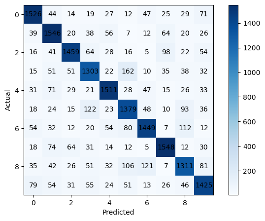

```
==========Misclassfied images===============
List of misclassified images: [0, 8, 11, 29, 37, 40, 46, 47, 56, 57, 58, 64, 67, 68, 85, 89, 90, 92, 97, 100, 102, 108, 125, 127, 128, 132, 137, 138, 140, 142, 150, 151, 154, 155, 156, 158, 163, 170, 176, 182, 183, 184, 194, 200, 203, 210, 222, 223, 230, 232, 235, 239, 246, 251, 252, 253, 256, 267, …
Total count of misclassified images 3543
```

```python
print('=============Classification Report==========')
print(classification_report(preserved_actual_Y_test,Y_pred_final))

print('============Confusion Matrix================')
cm=confusion_matrix(preserved_actual_Y_test,Y_pred_final)
plt.figure(figsize=(8, 5))
plt.imshow(cm, cmap='Blues', interpolation='nearest')
plt.colorbar()
plt.xlabel('Predicted')
plt.ylabel('Actual')
for i in range(len(cm)):
    for j in range(len(cm[i])):
        plt.text(j, i, str(cm[i][j]), ha='center', va='center', color='black')
plt.show()

print("==========Misclassfied images===============")
index = 0
misclassified_images = []
for label, predict in zip(preserved_actual_Y_test, Y_pred_final):
    if label != predict:
        misclassified_images.append(index)
    index +=1
print("List of misclassified images:",misclassified_images)
print("Total count of misclassified images",len(misclassified_images))
```

#### D. Plot the training loss, validation loss vs number of epochs and training accuracy, validation accuracy vs number of epochs plot and write your observations on the same. [4 Marks]

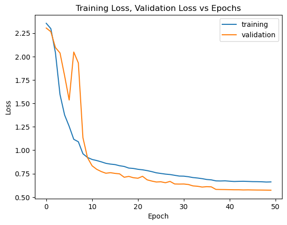

```python
h = pd.DataFrame(history.history)
h['epoch'] = history.epoch
plt.xlabel('Epoch')
plt.ylabel('Loss')
plt.title("Training Loss, Validation Loss vs Epochs")
plt.plot(h['loss'])
plt.plot(h['val_loss'])
plt.legend(("training" , "validation") , loc=0);
```

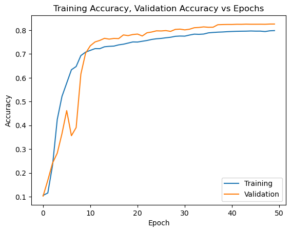

```python
plt.title("Training Accuracy, Validation Accuracy vs Epochs")
plt.plot(h['accuracy'])
plt.plot(h['val_accuracy'])
plt.xlabel('Epoch')
plt.ylabel('Accuracy')
plt.legend(("Training" , "Validation") , loc=0);
```